# MB5370

Darius HUISMAN

2026-05-20

# Introduction

This code contains the work realised during the first module of MB5370.

It is structured at follow: - Workshop 1 - Foundations Focus on the comprehension of key principles of R, including its ecosystem, syntax/scripts, packages, data types, data structures, R projects architecture, Qmd/Rmd and sourcing scripts. * Note that the code related to this workshop is in a single chunk because it was firt written in an R script then transfered in this Rmd script. - Workshop 2 - Visualisation Focuss on the development of visuals to investigate datasets using ggplot, how to face troubleshooting, and optinmisations of visuals, including the integration of statistical details on plots. - Workshop 4 - The Developer’s Toolbox & AI Learn how to use GitHub Copilot and conversational contexts (chattr) inside RStudio, as well as to build scalable, automated and error proff functions using functional iterations.

# Workshop 1

```r
#source("../MB5370/MB5370_W1.R")
```

```r
#----------------------------------------------#
#MB5370: Introduction to programming
#Darius HUISMAN
# May 2026

#Workspace:
# ~/Desktop/MB5370/MB5370_W1.R
#----------------------------------------------#

#----------------------------------------------#
# Workshop 01. Introduction ####

# Getting started ####
# This section introduces us to R by using it as a simple calculator.

# Variables and Assignment ####
# This section focuses on understanding how data is stored in R and why that matters.

age <- 25
first_name <- 'Bill'

Age <- 41 # cases matter

  # Exercise ####
a <- 15 + 25.1 + 20.25
b <- 26
c <- a + b

# Functions ####

years_old <- 25.7
round(years_old) # rounds up
```

```
## [1] 26
```

```r
floor(years_old) # rounds down
```

```
## [1] 25
```

```r
years_old <- 25.765
round (years_old, 2) # comma after the object to specify argument
```

```
## [1] 25.76
```

```r
?round # go to help

args(round) # use args in the Console
```

```
## function (x, digits = 0, ...)
## NULL
```

```r
  # Exercise
my_age <- 26
my_name <- 'Darius'

?paste # go to help

paste(my_name, "is", my_age, "years old.")
```

```
## [1] "Darius is 26 years old."
```

```r
# Debugging ####

# Misconceptions
# variables in programs do not work the same way as they do in spreadsheets
grade <- 55
total <- grade + 10
print (total)
```

```
## [1] 65
```

```r
grade <- 90
print (total) # value of total in a spreadsheet will be 100, but in programming a variable holds the value it was assigned (65)
```

```
## [1] 65
```

```r
total <- grade + 10
print (total) # executed in the way it was defined
```

```
## [1] 100
```

```r
# What will this code do?
p <- 2
z <- 5
out <- p * z  # What should the value of out be?
print (out) # What is the value of out? Is it the same as expected?
```

```
## [1] 10
```

```r
# Testing
x <- 1
is.character(x)
```

```
## [1] FALSE
```

```r
is.numeric (x)
```

```
## [1] TRUE
```

```r
  # Exercise
#my_quiz <- c("uno",
#             "dos",
#             "tres",
#             "cuatro" # missing a ",", causing an error
#             "cinco")
#print (my_quis) # syntax error, should be "my_quiz"
#str(my_quiz)
#len(my_quiz) # wrong function / function does not exist

# errors fixed
my_quiz <- c("uno",
             "dos",
             "tres",
             "cuatro", # corrected
             "cinco")
print (my_quiz) # corrected
```

```
## [1] "uno"    "dos"    "tres"   "cuatro" "cinco"
```

```r
str(my_quiz)
```

```
##  chr [1:5] "uno" "dos" "tres" "cuatro" "cinco"
```

```r
length(my_quiz) # corrected
```

```
## [1] 5
```

```r
# Data types ####

  #Exercise
#numeric
my_numeric_variable = 4.2
class(my_numeric_variable)
```

```
## [1] "numeric"
```

```r
#character
my_name <- 'Darius'
class(my_name)
```

```
## [1] "character"
```

```r
#integer
int <- 1L
class(int)
```

```
## [1] "integer"
```

```r
#logical
t <- TRUE
class(t)
```

```
## [1] "logical"
```

```r
# Data structure ####

# Vector
y <- c(1, 2, 3)
z <- c("Sarah", "Tracy", "Jon")

  # Exrecise
class(x)
```

```
## [1] "numeric"
```

```r
class(y)
```

```
## [1] "numeric"
```

```r
## both are numeric

# List
x <- list(1, "a", TRUE)
x
```

```
## [[1]]
## [1] 1
##
## [[2]]
## [1] "a"
##
## [[3]]
## [1] TRUE
```

```r
x[[2]]
```

```
## [1] "a"
```

```r
# Data frame and tibbles
my_data_frame <- data.frame(no = c(1,2,3), name = c("Tracey", "John", "Pete"), "True or False" = c(TRUE, FALSE, TRUE))
my_data_frame
```

```
##   no   name True.or.False
## 1  1 Tracey          TRUE
## 2  2   John         FALSE
## 3  3   Pete          TRUE
```

```r
str (my_data_frame)
```

```
## 'data.frame':    3 obs. of  3 variables:
##  $ no           : num  1 2 3
##  $ name         : chr  "Tracey" "John" "Pete"
##  $ True.or.False: logi  TRUE FALSE TRUE
```

```r
my_data_frame$no = as.factor(my_data_frame$no)
str (my_data_frame)
```

```
## 'data.frame':    3 obs. of  3 variables:
##  $ no           : Factor w/ 3 levels "1","2","3": 1 2 3
##  $ name         : chr  "Tracey" "John" "Pete"
##  $ True.or.False: logi  TRUE FALSE TRUE
```

```r
# Packages and Libraries ####

# install.packages('tidyverse') # download and install
library(tidyverse) # load into current workspace
```

```r
# install.packages ('ggplot2') # comment out so it doesn’t run again

# install.packages("ggplot","tidyr", "earthtones","redlistr","dplyr" ,"terra")

library (ggplot2)
?ggplot2

# Coding best practices ####

# load packages
library(ggplot2)
library(tidyr)
library(tidyverse)

  # Class discussion
    # 1. Read the .csv dataset into R using the 'read_csv' function
    # 2. Check the data file donwloaded (make sure the file has been read correctly and spot potential data that could cause problem)
    # 3. Analyse the abundance of each species
    # 4. PLot the species abundance of the species of you want
```

# Workshop 2

This workshop aims to develop and master our skills in data visualisation using ggplot2

## 2.16 Load packages and data

```r
#install.packages("tidyverse")
library(tidyverse)
library(ggplot2)
```

```r
mpg
```

```
## # A tibble: 234 × 11
##    manufacturer model      displ  year   cyl trans drv     cty   hwy fl    class
##    <chr>        <chr>      <dbl> <int> <int> <chr> <chr> <int> <int> <chr> <chr>
##  1 audi         a4           1.8  1999     4 auto… f        18    29 p     comp…
##  2 audi         a4           1.8  1999     4 manu… f        21    29 p     comp…
##  3 audi         a4           2    2008     4 manu… f        20    31 p     comp…
##  4 audi         a4           2    2008     4 auto… f        21    30 p     comp…
##  5 audi         a4           2.8  1999     6 auto… f        16    26 p     comp…
##  6 audi         a4           2.8  1999     6 manu… f        18    26 p     comp…
##  7 audi         a4           3.1  2008     6 auto… f        18    27 p     comp…
##  8 audi         a4 quattro   1.8  1999     4 manu… 4        18    26 p     comp…
##  9 audi         a4 quattro   1.8  1999     4 auto… 4        16    25 p     comp…
## 10 audi         a4 quattro   2    2008     4 manu… 4        20    28 p     comp…
## # ℹ 224 more rows
```

## 2.17 Create your first ggplot

```r
ggplot(data = mpg) +
  geom_point(mapping = aes(x = displ, y = hwy))
```

[output not shown]

## 2.18 Understand the ‘grammar of graphics’

### 2.18.1 Graphing template

```r
#ggplot(data = mpg)
```

### 2.18.2 Aesthetic mappings

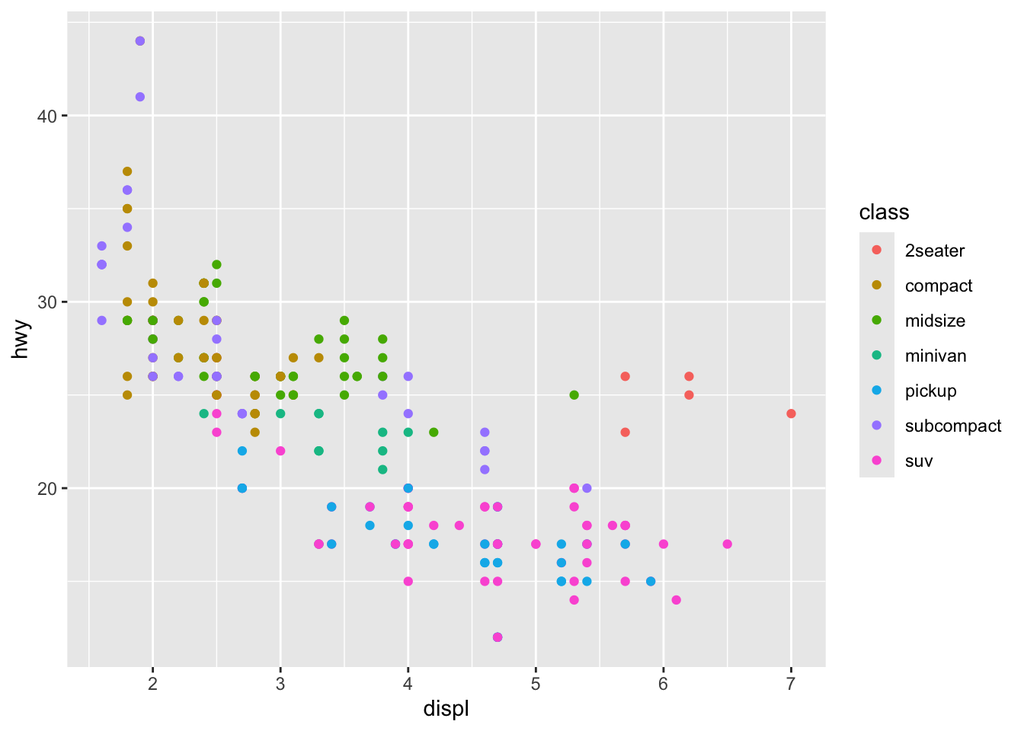

```r
ggplot(data = mpg) +
  geom_point(mapping = aes(x = displ, y = hwy, colour = class))
```

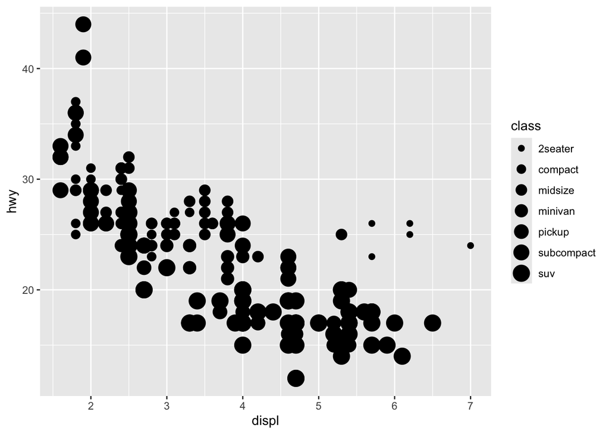

```r
#change point size by class
ggplot(data = mpg) +
  geom_point(mapping = aes(x = displ, y = hwy, size = class))
```

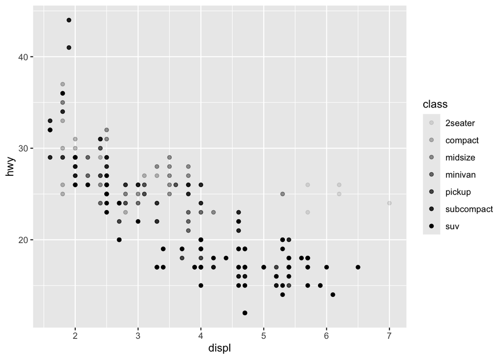

```r
#change point transparency by class
ggplot(data = mpg) +
  geom_point(mapping = aes(x = displ, y = hwy, alpha = class))
```

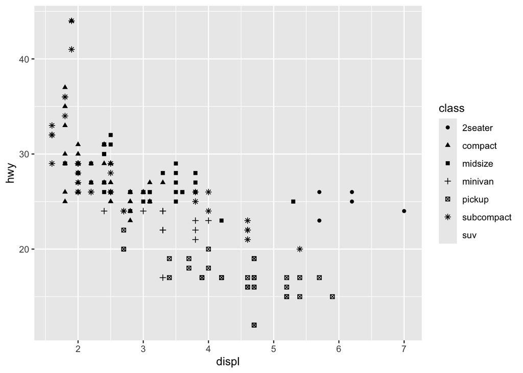

```r
#change point shape by class
ggplot(data = mpg) +
  geom_point(mapping = aes(x = displ, y = hwy, shape = class))
```

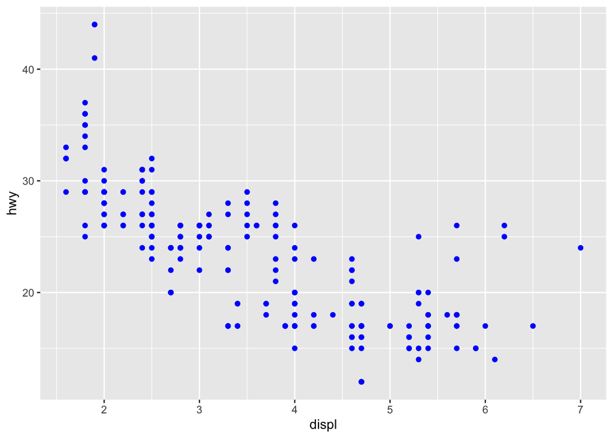

```r
# all points blue
ggplot(data = mpg) +
  geom_point(mapping = aes(x = displ, y = hwy), color = "blue")
```

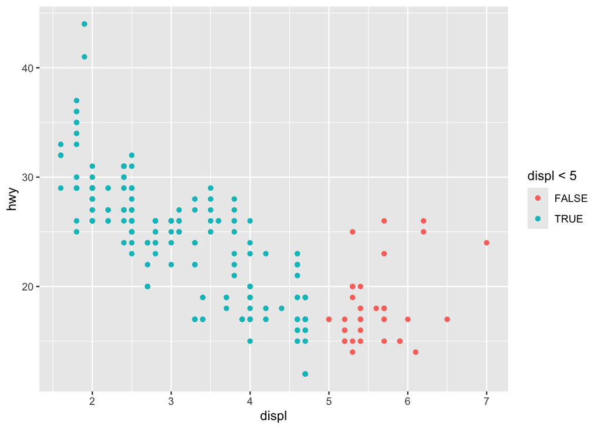

```r
#distinct displ data < 5
ggplot(data = mpg) +
  geom_point(mapping = aes(x = displ, y = hwy, color = displ < 5))
```

## 2.19 Troubleshooting

```r
ggplot(data = mpg) +
  geom_point(mapping = aes(x = displ, y = hwy))
```

[output not shown]

```r
# the + should be on top line
```